REVIEW

Open Access

Are ketogenic diets promising for

Alzheimer’s disease? A translational review

Matthieu Lilamand<sup>1,2,3*</sup>†, Baptiste Porte<sup>1,2</sup>†, Emmanuel Cognat<sup>1,2</sup>, Jacques Hugon<sup>1,2</sup>, François Mouton-Liger<sup>1,2</sup>and

Claire Paquet<sup>1,2</sup>

Abstract

Background: Brain amyloid deposition and neurofibrillary tangles in Alzheimer’s disease (AD) are associated with

complex neuroinflammatory reactions such as microglial activation and cytokine production. Glucose metabolism is

closely related to neuroinflammation. Ketogenic diets (KDs) include a high amount of fat, low carbohydrate and

medium-chain triglyceride (MCT) intake. KDs lead to the production of ketone bodies to fuel the brain, in the

absence of glucose. These nutritional interventions are validated treatments of pharmacoresistant epilepsy,

consequently leading to a better intellectual development in epileptic children. In neurodegenerative diseases and

cognitive decline, potential benefits of KD were previously pointed out, but the published evidence remains scarce.

The main objective of this review was to critically examine the evidence regarding KD or MCT intake effects both in

AD and ageing animal models and in humans.

Main body: We conducted a review based on a systematic search of interventional trials published from January

2000 to March 2019 found on MEDLINE and Cochrane databases. Overall, 11 animal and 11 human studies were

included in the present review. In preclinical studies, this review revealed an improvement of cognition and motor

function in AD mouse model and ageing animals. However, the KD and ketone supplementation were also

associated with significant weight loss. In human studies, most of the published articles showed a significant

improvement of cognitive outcomes (global cognition, memory and executive functions) with ketone

supplementation or KD, regardless of the severity of cognitive impairments previously detected. Both interventions

seemed acceptable and efficient to achieve ketosis.

Conclusion: The KD or MCT intake might be promising ways to alter cognitive symptoms in AD, especially at the

prodromal stage of the disease. The need for efficient disease-modifying strategies suggests to pursue further KD

interventional studies to assess the efficacy, the adherence to this diet and the potential adverse effects of these

nutritional approaches.

Keywords: Ketogenic diet, Alzheimer’s disease, Brain metabolism, Animal models

[figure not shown]

* Correspondence: mlilamand@hotmail.fr

†Matthieu Lilamand and Baptiste Porte contributed equally to this work.

1INSERM U1144 Optimisation Thérapeutique en Neuropsychopharmacologie,

Université de Paris, Paris, France

2Centre de Neurologie Cognitive/CMRR Paris Nord Ile de France, APHP Nord

Université de Paris, Lariboisière Hospital 200, rue du Faubourg Saint Denis,

75010 Paris, France

Full list of author information is available at the end of the article

[figure not shown]

Lilamand et al. Alzheimer's Research & Therapy (2020) 12:42

https://doi.org/10.1186/s13195-020-00615-4

Background

Carbohydrates represent the primary energy source for

the brain. However, when glucose is not readily available

(e.g. starvation), a metabolic switch occurs in favour of

ketone bodies (KB), usually released by the liver. The di-

ets specifically designed for KB production are called ke-

togenic diets (KDs) [1, 2]. They are the first and only

nutritional interventions that enabled a significant re-

duction in the incidence of seizures in pharmacoresis-

tant epilepsy [3] or in chronic cluster headaches [4]. The

core characteristics of the KD are the association of a

high amount of fat, with low carbohydrate intake, usually

a macronutrient ratio of fat to protein and carbohydrate

combined equal to 3–4:1. Alternative KDs were devel-

oped using ketone supplementation (KS), in which fats

are provided with medium-chain triglyceride (MCT) in-

take. Their common objective is to achieve ketosis, lead-

ing to reduced insulin secretion and glycaemia within

48 h, as well as a shift in the brain’s metabolism [2].

In Alzheimer’s disease (AD), it is described numerous

interrelations between abnormal glucose metabolism

and the occurrence of brain lesions. First, AD could be a

partial consequence of insulin resistance, which affects

insulin signalling and favours in the brain abnormal de-

position of β-amyloid peptide (Aβ) and phosphorylated

tau (pTau) accumulation, leading in turn to cognitive

decline [5]. Furthermore, the expression of apolipopro-

tein E allele 4 (APOE4) is a common risk factor for AD

and for type 2 diabetes suggesting a common patho-

physiological background [6]. As demonstrated by fluoro-

deoxyglucose positron emission tomography (FDG-PET),

abnormal brain glucose metabolism in the temporal and

parietal lobes occurs from the earliest stages in AD animal

models and AD patients but also in asymptomatic individ-

uals at risk for AD [7]. Interestingly, these hypometabolic

regions are still able to take up KB, even though they can

no longer utilize glucose [8].

At the cellular level, several KD neuroprotective effects

have been observed, linked to various mechanisms: (i)

reduction of the concentration of several excitatory neu-

rotransmitters (e.g. glutamate) [9], (ii) stabilization of

synaptic functions due to enhanced mitochondrial bio-

genesis [10] and (iii) reduction of reactive oxygen species

generation and increase adenosine triphosphate avail-

ability [11]. Moreover, KB have specific protective effects

against cerebral Aβ toxicity and cell damage as shown in

rat cultured hippocampal neurons [12]. Aβ can induce

neuroinflammation, which is a current therapeutic target

in AD. KD could modulate Aβ toxicity by promoting the

action of endogenous anti-inflammatory molecules such

as peroxisome proliferator-activated receptor γ, leading

to a decreased systemic inflammation [13].

These observations, as well as the current lack of suc-

cess of anti-AD therapies or nutritional interventions to

change the course of AD, suggest that KD or KS might

be of therapeutic interest in these patients. A potential

benefit of KDs in AD was already claimed in media and

some scientific reports [14, 15]. However, as few works

have brought about a critical review of existing data, we

hereby propose a comprehensive and translational re-

view of KD efficiency in both preclinical and clinical AD

or ageing studies. Thus, the main objective of this review

was to assess the effects of ketogenic interventions on

clinical and metabolic outcomes (e.g. cognitive function,

brain metabolism) or AD biomarkers, both in experi-

mental animals and in humans. We will also examine

the potential side effects of ketogenic interventions in

these populations, in terms of nutritional change and ad-

verse effects.

Research process

We performed a systematic search in accordance with

the Preferred Reporting Items for Systematic Reviews

and Meta-Analyses (PRISMA) guidelines [16]. We iden-

tified all published articles between January 2000 and

March 2019 on MEDLINE and Cochrane databases

using the Medical Subject Heading (MeSH) terms “keto-

genic diet” or “medium-chain triglyceride” and assorted

combinations of the following terms: “Alzheimer’s dis-

ease”, “Alzheimer”, “cognition” and/or “memory”. We only

included interventional studies using either KD or KS. We

have excluded studies published in languages other than

English, focusing on KD diet effects in diseases other than

AD or performed in cellular models. Titles and abstracts

were the base of the initial screening. We evaluated the

eligibility of selected articles after full-text readings. We

also examined all papers cited in the selected articles. We

added additional references, based on their originality

and/or relevance regarding the scope of this review. Data

extraction was performed by six authors (ML, BP, EC,

FML, JH, CP), using a standardized extraction form. This

tool assessed the study design, population (number of ani-

mals/participants, animal model/ageing individuals or AD

patients), type of ketogenic intervention, outcomes (e.g.

biological endpoint, clinical endpoint, neuroimaging end-

point), follow-up duration, nutritional changes and poten-

tial side effects due to the intervention. This search was

carried out in April 2019.

Results

tional studies were found through the bibliography of the

relevant animal studies papers. In total, 22 (11 animal

studies and 11 human studies) were considered relevant

for the present review. We summarized details of animal

and human studies in Tables 1 and 2, respectively. Figure 1

outlines the results of the systematic searches.

Preclinical studies

Two types of interventions were used: KD (N = 7) either

ad libitum or calorie-controlled, and KS (N = 4), com-

pared to control diet or placebo, respectively. Even if the

total number of animals varied from one study to the

same. Overall, baseline age at the start, species or AD

model type, sex and follow-up duration varied between

studies.

Ageing animals

Five studies assessed ketogenic interventions in ageing

animals. The mean age at baseline varied depending on

the studied species: 9 years for beagle dogs (N = 1), above

20 months for wild-type (WT) rats (N = 3) and 12

months for WT mice (N = 1). Only two studies out of

animals [20, 21]. Three studies used only ageing male

rodents [20, 23, 27] whereas two other studies compared

the effect of KD/KS on ageing males and females [21,

24]. The follow-up duration was different according to

species: 8 or 12 weeks for WT rats [20, 21, 27], 32 weeks

for beagle dogs [24] and 72 weeks for old WT mice on

which the effect of KD on life span was evaluated [23].

Alzheimer’s disease animal models

Six studies included different AD mouse models, based

on the amyloid cascade hypothesis. Briefly, 3xTgAD

mice [22, 25], APP/PS1 mice [17, 18], APP [V7171] mice

[26] and APP+PS1 [19] mice were used. Interestingly,

Brownlow et al. choose to compare an amyloid-based

AD model (APP+PS1 mice) and a tau-based AD model

(Tg4510 AD mice) [19]. One of these studies used only

female AD mouse model (APP [V7171]) [26]. Regarding

baseline age, 3xTgAD mice were older (8.5 months) than

APP [V7171] (3 months), APP/PS1 (between 1 and 3

months) and APP+PS1 and Tg4510 mice (5 months).

The follow-up duration varied from 4 to 32 weeks (mean

17 ± 5.05 weeks) without a link between duration and a

type of AD model.

Outcomes and results

The following objectives were assessed: efficacy on cog-

nition and/or motor functions (N = 3 assessing both,

N = 5 assessing cognition only, N = 1 assessing motor

Table 1 Animal studies discussed in the present review

Study 1st

author (ref)

Models

Intervention

Number FU

Outcomes

Positive results

(intervention group)

Nutritional changes

(vs ctrl group)

Aso [17]

APP/PS1 mice KD + triheptanoin

vs KD

28

12

Cognition, AD features

inflammation markers

Cognition and

neuroinflammation

Unassessed

Beckett [18]

APP/PS1 mice KD ad libitum

65

4

Motor functions, AD

features, oxidative

stress

Motor coordination (rotarod) Weight loss

Brownlow [19]

APP/PS1 and

Tg4510 mice

KD ad libitum

60

16

Cognition, motor

unctions, AD features

Motor coordination (rotarod) Stable weight

Hernandez [20]

Young vs old

WT rats

KD cal ctrl

56

12

Body composition,

transporter expression

Less adipose tissues

and reversed age-

related transporters

evolution

Unassessed

Hernandez [21]

Young vs old

WT rats

KD cal ctrl

39

12

Cognition, transporter

expression

Cognition and

reversed age-related

transporters evolution

Weight loss in

old rats

Kashiwaya [22]

3xTgAD mice

KS vs CD

30

32

Cognition, AD features Cognition and AD

features

Weight loss

Newman [23]

Young vs old

WT mice

Cyclic KD ad libitum 58

72

Cognition, motor

functions, health

span, gene expression

Cognition and

reduced mid-life

mortality

Stable weight

Pan [24]

Old beagle

dogs

KS vs CD

24

32

Cognition

Cognition

Stable weight

Pawlosky [25]

3xTgAD mice

KS vs CD

24

32

Metabolism, protein

expression

Reduced protein

oxidation and BACE

1 expression

Weight loss

Van der Auwera [26]

APP/V717I

mice

KD ad libitum,

crossover

16

6

Cognition, AD

features

Reduced brain

total Aβ

Weight loss

Wang [27]

Old WT rats

KS (MCT 8 or 10)

vs CD

36

8

Cognition, synapse

pathway

Cognition and

synaptic stability

Weight loss

Aβ beta-amyloid peptide, AD Alzheimer’s disease, BACE 1 beta-secretase 1, cal ctrl calorie-controlled, CD control diet, ctrl control, FU follow-up duration (given in

weeks), KD ketogenic diet, KS ketone supplementation

Table 2 Human studies discussed in the present review

Study 1st

author (ref)

Population

Mean age

(SD)

Intervention

N

Design

FU

Outcomes

Positive outcomes

(intervention group)

Plasma KB

levels

Nutritional

changes

Side effects

Fortier [28]

MCI

75.4 (6.6)

KS vs placebo

52

RCT

26

MMSE, MoCa, brain

PET imaging

Imaging (but not

cognition)

Yes

Stable weight

No adverse

effect

Ota [29]

Mild-moderate AD

73.4 (6.0)

KS vs control

20

RCT

12

Memory, executive

function

Cognition

Yes

Unassessed

Unassessed

Torosyan [30]

Mild-moderate AD

79.9 (9.2)

KS vs control

14

RCT

6

Brain PET imaging

Imaging

No

Unassessed

Unassessed

Taylor [31]

MCI or AD dementia

73.1 (9.0)

KS

15

No control

group

12

ADAS-cog, MMSE,

feasibility

Cognition

Yes

Stable weight,

cholesterol,

glucose

Unassessed

Abe [32]

Nursing home

residents

86.6 (4.8)

KS + vitD + leucine

vs vitD leucine vs

control

38

RCT

12

MMSE

Cognition

No

Improved muscle

mass and function

Unassessed

Ota [33]

60+ adults no dementia

66.1 (2.9)

KS vs placebo

19

Crossover, RC

0

Memory, executive

function

Cognition

Yes

Unassessed

Unassessed

Ohnuma [34]

Mild moderate AD

63.9 (8.5)

KS vs control

22

RCT

12

MMSE

None

Yes

Unassessed

Unassessed

Rebello [35]

MCI

Not available

KS vs control

6

RCT

24

ADAS-cog,

TMT, DST

Inconclusive

Yes

Stable weight

No adverse

effect

Krikorian [36]

MCI

70.1 (6.2)

KD vs CD

23

RCT

6

Executive function,

memory

Cognition

No (urinary

tests)

Weight loss

No adverse

effect

Henderson [37]

Mild-moderate AD

76.9 (7.9)

KS vs placebo

152

RCT

12

ADAS-cog, ADCS-CGIC

Cognition

Yes

Unassessed

Frequent GI

symptoms

Reger [38]

MCI or AD dementia

74.7 (6.7)

KS vs placebo

20

Crossover, RC

0

ADAS-cog, MMSE,

word recall, Stroop

Cognition

Yes

Unassessed

Unassessed

AD Alzheimer’s disease, ADAS-cog Alzheimer Disease Assessment Scale, ADCS-CGIC Alzheimer’s Disease Cooperative Study Clinical Global Impression of Change, CD control diet, DST Digit Symbol Test, FU follow-up

duration, GI gastrointestinal, KB ketone bodies, KD ketogenic diet, KS ketone supplementation, MCI mild cognitive impairment, MoCA Montreal Cognitive Assessment, N number, MMSE Mini-Mental Status Examination,

PET positron emission tomography, RCT randomized controlled trial, TMT Trail Making Test, vitD vitamin D

function only), impact on neuropathological AD lesions

(N = 5), KD safety (N = 1) and weight variations (N = 9).

Eight studies (one in old WT mice, two in young vs age-

ing WT rats and five in AD mouse models) evaluated

multiple outcomes.

In ageing animals

Three studies evaluated the effects of KD in ageing ani-

mals, either on safety and cognition [23], weight and

neurotransmitter function [20] or cognition/motor func-

tion and neurotransmitter function [21].

Effects of KD/KS on life expectancy and mortality

Only Newman et al. conducted a long-term study of KD.

They showed that KD was able to reduce mid-life mor-

tality but without improving maximum lifespan in old

C57Bl6 WT mice [23].

Cognitive and motor impact of KD/KS

Four studies evaluated the cognitive impact of KD and

showed a positive effect on cognition, in ageing animals

suggests that brain metabolism can shift towards the use of

KB, regardless of the kind of ketone-oriented diet used,

with potential cognitive gain. Similarly, motor performances

were improved in all studies, regardless of potential associ-

ated cognitive benefits. These results are consistent with

many mouse studies demonstrating that keto-adaptation

enhanced the capacity to transport and metabolize fat as

well as motor abilities and recovery [39–41].

Mechanisms underlying cognitive effects of KD and KS

Hernandez et al. studied the effect of KD on transport

vesicular

glutamate

and

gamma-aminobutyric

acid

of vesicular GABA transporter expression in the hippo-

campus and in the prefrontal cortex. This result could

be linked to the known effect of KD in epilepsy [3]. In-

deed, KD enhances GABA vesicular filling which main-

tains

an

inhibitory

feedback

associated

with

the

beneficial effect of KD. One can also hypothesize that

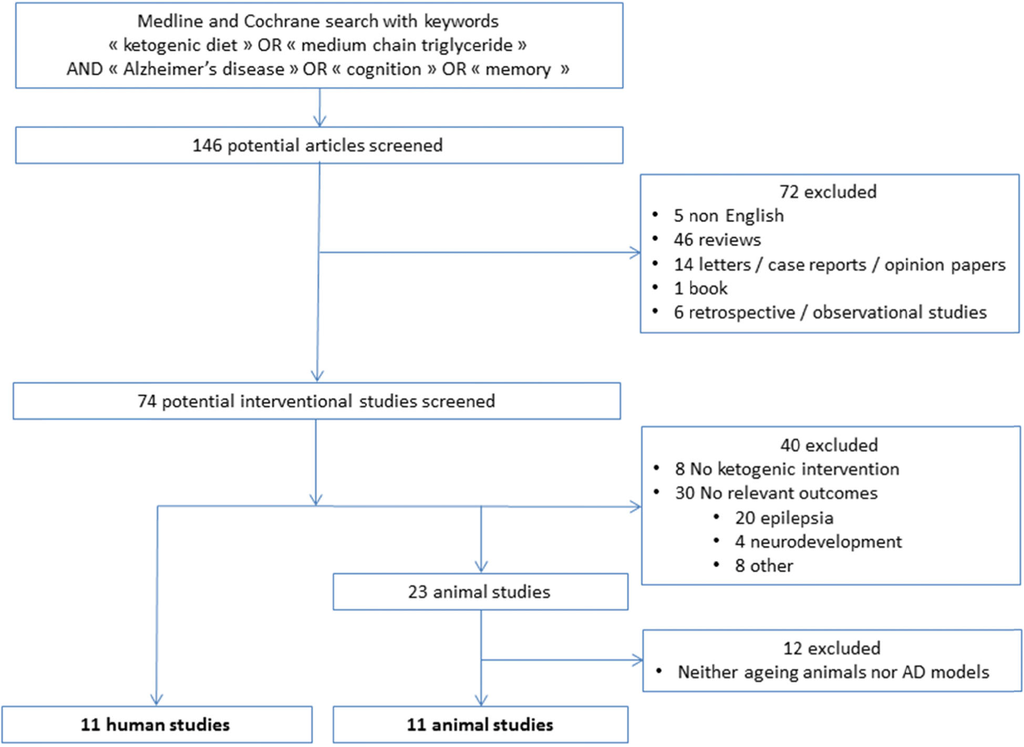

Fig. 1 Flow diagram of studies selection

this effect on GABA may have a potential anxiolytic ef-

fect. Interestingly, the authors described a similar rever-

sal effect on the age-dependent decrease of vesicular

glutamate transporter expression that was not restricted

to the hippocampus.

In addition, Wang and Mitchell described that KS is

associated, in old WT rats, with an increase in insulin

receptor 1 levels and Akt phosphorylation and a de-

crease in ribosomal protein S6 kinase phosphorylation

[27]. KS effect on this pathway is associated with in-

creased ube3a expression that notably plays a role in

synaptic stabilization. Conversely, Newman et al. identi-

fied a downregulation of the insulin pathway in old WT

mice fed with KD ad libitum [23]. The conflicting results

of the two studies can be due to the discrepancies con-

cerning the duration of diet (8 vs 72 weeks) and/or the

baseline age of the animals (21 vs 12 months). So far,

data are not sufficient to conclude on the mechanisms

responsible for the cognitive impact of KD/KS in ageing

brain or whether there even is an impact. However, if

there is an effect of KD/KS on cognition, one first hy-

pothesis might be synaptic protection through neuro-

transmitter pathway and/or synaptic stabilizations.

Effects of KD/KS on weight

the two others [23, 24]. Among the four, only Hernan-

dez et al. observed a significant weight loss despite a

calorie-controlled KD. This effect was specific to old

WT rats, but an unexpected fat mass reduction was ob-

served both in young and old WT rats [20].

In Alzheimer’s disease animal models

In details, five studies using AD mouse models assessed

cognition and/or motor function together with histo-

Cognitive and motor impact of KD/KS

Two studies assessed the cognitive impact of KD in AD

likely to result from an enhanced mitochondrial func-

tion, due to triheptanoin supplementation [17]. In the

other study, motor coordination was significantly im-

proved in the KD group.

Effects of KD/KS on AD pathological lesions

Five studies specifically assessed the changes in Aβ and/

or tau deposition in AD mouse models [17–19, 22, 26].

Kashiwaya et al. and Van der Auwera et al. described a

decrease in Aβ deposition in the brain of KD-fed female

tion of abnormal pTau labelling in the hippocampal neu-

et al. failed to report any significant improvement in

brain amyloid load after KD in APP/PS1 [17, 18],

APP+PS1 and Tg4510 (tau) AD mouse models [19].

Several factors or combined factors could explain this

discrepancy, but we will focus on the two mains: (i) type

of diet and/or its duration and (ii) type of AD model and

time course of lesion onset. Regarding diet, the duration

of the intervention might have played a role in the ob-

served discrepancy. Indeed, this effect on Aβ accumula-

tion and pTau pathology in 3xTgAD mice was described

when an animal received a KS for 32 weeks [22]. This re-

sult may also be due to a specific therapeutic effect of

the synthetic ketone ester (R)-3-hydroxybutyrate-(R)-1,

3-butanediol

monoester,

administered

as

a

dietary

supplement.

The choice of an AD mouse model is crucial in this

setting. All AD mouse models used are based on the

overexpression of Aβ, but they differed in terms of the

type and/or the pathological time course of the disease.

Thus, promoters regulating the mutated gene expression

are model-dependent and so is Aβ production and accu-

mulation. AD models with high Aβ production and ac-

cumulation like 3xTgAD (combining amyloidopathy and

tauopathy) or APP [V7171] (early-onset familial AD)

were the ones in which the effect of the ketogenic inter-

ventions

was

observed

[22,

26].

KD,

like

calorie-

restricted diet, might induce insulin-degrading enzymes

directed against Aβ [42]. Accordingly, an effect on Aβ

accumulation based on degradation is easier to observe

in animals with higher Aβ accumulation. In addition, the

time course of the lesions depends on model types.

Therefore, if the aim of the intervention is to evaluate

the effect on Aβ load, the intervention has to take into

account this parameter. For example, in APP/PS1 mice,

soluble Aβ became detectable from 3 months onward

and amyloid plaques appeared at 9 months. Studying the

effect of KD/KS before those milestones or with an early

endpoint may lead to the absence of observed effect [17,

18]. It is also interesting to note that the type of pro-

moter also affects the magnitude of Aβ load. For ex-

ample, the prion protein promoter, present in APP+PS1

and APP/PS1, is responsible for a more widespread and

less

selective

Aβ

expression

than

others

[43].

Localization of amyloid brain load may differ from one

animal model to the other, and analyzing methods have

to be adapted. Thus, analysis restricted to specific brain

regions (e.g. Aβ immunochemical labelling in the pre-

frontal cortex or hippocampus [24]) seems to be more

efficient than global analysis (e.g. whole-brain enzyme-

linked immunosorbent assay against total Aβ and APP

C-terminal [25]).

Regarding other abnormal features in models of AD,

Aso et al. showed a reduction of neuroinflammation

after intake of KD + triheptanoin in APP/PS1 mouse that

was not observed in APP/PS1 mouse fed with KD only

and thus might be specific to triheptanoin supplementa-

tion [17]. Pawlosky et al. observed that KS induced a re-

duction of the free radical insult against hippocampal

proteins and modified both α- and β-secretase expres-

sion levels (higher and lower respectively) in hippocam-

pal but not in cortical lysates [25]. KS is able to reduce

the levels of hippocampal BACE 1, a key enzyme in the

production of Aβ peptide, and this finding could explain

the reduction of amyloid load.

Overall, KD and KS seemed to be able to reduce Aβ

and pTau load as well as neuroinflammation, especially

in aggressive mouse models treated for a long time. In

some models, those neuropathological effects were asso-

ciated with improvement of cognitive and/or motor

functions. While the underlying mechanisms remain to

be elucidated, these observations support the hypothesis

that KD/KS might have definite therapeutic actions on

AD abnormal biological pathways.

Effects of KD/KS on weight

Four studies, using various methodologies, observed a

significant weight loss [18, 22, 25, 26], while no body

weight modifications were observed in the last one [19].

Thus, while these studies used variable material and ap-

proaches, most of them found a reproducible weight loss

induced by KD or KS. However, details are lacking to

draw definite conclusions on the mechanisms of this

weight loss and its consequences on the safety of this ap-

proach. There was no reported association of weight loss

to cognitive change in these studies.

Clinical studies

General characteristics of the studies

Included humans studies (N = 11) are presented in

Table 2. They involved either ageing subjects with or

without mild cognitive impairment (MCI) (N = 6; mean

Examination (MMSE) score at baseline 17.1 to 27.1) or

individuals with AD dementia based on clinical diagnos-

tic criteria such as the Diagnostic and Statistical Manual

of Mental Disorders-IV or the National Institute of

Neurological and Communicative Diseases and Stroke/

Alzheimer’s Disease and Related Disorders Association

(N = 5). In addition, these studies comprised inconsistent

sex ratios (30 to 66% of male). Five of them indicated an

average level of education between 12.5 and 15.3, and

only one provided information about the ethnic groups

of the study population (mostly Caucasians in 91%).

Thus, participants showed various degrees of cognitive

performance among studies, from normal ageing people

to moderate dementia. Two studies did not specify the de-

One can notice that the use of Aβ or tau biomarkers,

highly recommended for increasing diagnostic accuracy,

was not mentioned in these studies. APOE genotyping

was performed in four studies only [28, 30, 37, 38].

Regarding nutritional interventions, two studies used a

daily dose (20 to 56 g of MCT per day). Two studies had

included varied among studies from 6 to 152 (mean

examination of KS [28, 30, 37, 38].

None of the studies included in this review provided

details on patients’ medical conditions. Apart from cog-

nitive impairment, comorbidities are likely to modulate

the efficacy or the adhesion to KD or KS. For instance,

in patients with type 2 diabetes, very stringent KD may

not be sustainable over long-term, although there is no

formal contraindication to it [44]. Besides inflammatory

diseases, mood disorders, chronic pain and polyphar-

macy may change the nutritional status of the individ-

uals, as well as the safety of a high-fat diet. Moreover,

only Abe et al. presented its exclusion criteria: subjects

with body mass index < 23 kg/m<sup>2</sup>or major organ dys-

function [32]. Altogether, this impairs the external valid-

ity of the studies and pleads for new studies that would

assess the interaction between comorbidities and KD/KS

in patients.

Outcomes

All studies but one assessed cognitive changes after KS or

KD. One study focused on cognitive changes and the

feasibility of long-term KS in cognitively impaired individ-

studies used the Mini-Mental Status Examination [28, 31,

32, 34, 38], and four of them utilized the Alzheimer Dis-

ease Assessment Scale (ADAS-cog) [31, 35, 37, 38]. Two

studies used a neuroimaging (PET) endpoint: regional

cerebral blood flow [30] or [11C]-acetoacetate tracer [28].

Metabolic effects of KD/KS in cognitively impaired patients

and older adults

of KB to make sure that participants actually achieved

ketosis. Thus, the authors were able to demonstrate that

ketosis was quickly and efficiently reached in all the

studies, regardless of the type of intervention. However,

only five studies examined the changes in nutritional sta-

tus or body composition in patients under KS/KD [28,

31, 32, 35, 36]. Krikorian et al. highlighted a mean

weight loss of 4 kg per individual after 6 weeks, in MCI

adults under KD as compared to patients under control

diet [36]. This finding is consistent with the results of a

meta-analysis showing that KD is commonly associated

with weight loss, due to reduced total calorie intake [45].

Three other studies did not show any significant

weight change with KS [28, 31, 35]. Interestingly, Abe

et al. observed that participants improved their muscle

mass and function [32]. Of note, those subjects received

vitamin D and leucine in addition to the nutritional

intervention, which may have contributed to this ana-

bolic effect.

Finally, only four studies reported on the side effects

(49%), which led to treatment discontinuation (23% in

the intervention group).

Cognitive effects of KD/KS

Apart from the Torosyan et al. study (no clinical end-

significant

cognitive

improvements

in

the

intervention groups (KS or KD), regardless of partici-

did not report any significant effect on cognition [28, 34,

35]. Cunnane et al. previously mentioned that given a

choice between glucose and ketones, neurons would ra-

ther consume the latter [8]. Besides, even though brain-

imaging studies revealed that brain utilization of glucose

declines in early AD, KB utilization does not [46]. The

results of the two PET imaging studies evaluated for this

review were consistent with these findings [28, 30].

Interestingly, Torosyan et al. showed a long-term in-

crease in brain metabolism after KS in non-APOE4 indi-

viduals [30]. This is in line with the results of three

studies included in this review that highlighted better ef-

ficiency of KS in non-APOE4 subjects [30, 37, 38]. There

is also an established relationship between APOE4 geno-

type and brain amyloid deposition. It is noteworthy to

say that in the PREDIMED-NAVARRA randomized-

controlled trial, non-APOE4 genotype was associated

with greater improvement of the MMSE and Clock

Drawing Test scores when following a Mediterranean

diet rather than a Western-type diet [47]. Thus, the rela-

tionship between APOE4 status and cognitive effects of

metabolic interventions deserves further investigations.

Limitations of the studies

highly heterogeneous, in particular regarding age, gender

ratios or participants’ cognitive status, which all have a

significant effect on the risk of subsequent cognitive de-

cline. These limitations prevent from drawing robust

conclusions about the cognitive benefits of the ketogenic

interventions. Some results may also be questionable

such as an unexpected cognitive decline measured with

MCI individuals whereas in the intervention group, par-

ticipants maintained their cognitive level [37].

The short follow-up durations and the repeated cogni-

tive assessments are likely to be responsible for a retest

effect especially in cognitively intact or MCI individuals.

Conversely, patients with mild-to-moderate dementia

may be too severely impaired to observe benefits from

an intervention. This observation was previously raised

when discussing the failure of anti-amyloid therapies in

AD [48]. Furthermore, all studies aimed at measuring

short-term changes in cognition or brain metabolism.

The absence of long-term follow-up did not provide any

insight into the persistence of cognitive changes after

discontinuation of the nutritional intervention. Adhesion

to the KD or to KS intake must be carefully examined as

far as long-term nutritional changes are expected. Be-

sides, the monitoring of potential adverse effects is

mandatory, especially in AD, since nutritional status is a

key predictor of rapid cognitive decline as well as func-

tional limitations [49]. Finally, the small number of stud-

ies published so far raises the issue of a potential

publication bias as negative studies on the effects of KS

or KD on cognition could not be published.

Conclusion

Despite the growing interest for KD in AD over the last

years, only few interventional studies in animals or

humans clearly addressed the subject. In preclinical

studies, this review pointed out some interesting results

such as improvement of cognition and motor function

in some AD mouse model or ageing animals. The mech-

anisms leading to a benefic effect on cognition could be

due to the (i) modification in neurotransmitter transport

pathway and/or synaptic maintenance in ageing WT ani-

mals and (ii) improvement of abnormal features (Aβ

load or neuroinflammation) in AD mouse models. How-

ever, we must keep in mind that KD was initially created

(and is still popular) for inducing weight loss in healthy

or overweighed adults. In cognitively impaired subjects,

older adults or animal studies, it was also often associ-

ated with a significant weight loss. This consequence

could play an adverse effect on muscle performance (sar-

copenia) or even on cognitive decline. In humans,

notwithstanding the high heterogeneity of the studies

and methodological issues discussed above, most of the

published studies could suggest improved cognitive out-

comes (memory, executive function or global cognition)

with KS or KD, regardless of the severity of cognitive

impairment. Both interventions seemed acceptable for

included subjects and show efficacy to achieve ketosis.

KD and KS intake both offer different features and po-

tential benefits. They also present different disadvan-

tages. KD might be difficult to start in older adults with

modern eating habits and even more difficult to main-

tain. KS are useful to achieve ketosis but do not lead to

the same metabolic shift, since the brain is still being

fueled by glucose.

As a conclusion, the KD might be a promising way to

fight against the cognitive symptoms of AD, especially

from the prodromal stage of the disease (MCI). Regard-

ing the body of evidence discussed above, the hypothesis

that KD could postpone cognitive decline in AD should

be explored. Unlike omega-3 supplements or Ginkgo

biloba, the ketogenic interventions have not been evalu-

ated yet in large sample randomized controlled trials

with sufficient follow-up and structured cognitive and

neuroimaging outcomes. Therefore, further studies are

warranted, in particular, in adults with early AD, not

only to assess the efficiency of the KD on cognitive de-

cline, but also to examine the adverse effects (e.g. weight

loss, malnutrition) as well as the adherence to the diet.

Abbreviations

Aβ: β-Amyloid peptide; AD: Alzheimer’s disease; ADAS-cog: Alzheimer

Disease Assessment; ADCS-CGIC: Alzheimer’s Disease Cooperative Study

Scale Clinical Global Impression of Change; APOE4: Apolipoprotein E allele 4;

APP: Amyloid precursor protein; BACE 1: Beta-secretase 1; cal ctrl: Calorie-

controlled; CD: Control diet; DST: Digit Symbol Test; FDG: Flurodeoxyglucose;

FU: Follow-up; GABA: Gamma-aminobutyric acid; GI: Gastro-intestinal;

KB: Ketone bodies; KD: Ketogenic diet; KS: Ketone supplementation; MCI: Mild

cognitive impairment; MCT: Medium-chain triglyceride; MeSH: Medical

subject heading; MMSE: Mini-Mental Status Examination; MoCA: Montreal

Cognitive Assessment; PET: Positron emission tomography; PS: Presenilin;

pTau: Phosphorylated tau; RCT: Randomized controlled trial; TMT: Trail

Making Test; vitD: Vitamin D; WT: Wild-type

Acknowledgements

Not applicable.

Authors’ contributions

ML and BP analysed and interpreted the data and drafted the manuscript.

EC, JH and FML critically reviewed the selected studies and revised the

manuscript accordingly. CP conceived the original idea, reviewed the

selected studies and revised the final version of the manuscript. All authors

read and approved the submitted version.

Funding

Not applicable.

Availability of data and materials

Not applicable.

Ethics approval and consent to participate

Not applicable.

Consent for publication

Not applicable.

Competing interests

The authors declare that they have no competing interests.

Author details

1INSERM U1144 Optimisation Thérapeutique en Neuropsychopharmacologie,

Université de Paris, Paris, France. <sup>2</sup>Centre de Neurologie Cognitive/CMRR

Paris Nord Ile de France, APHP Nord Université de Paris, Lariboisière Hospital

200, rue du Faubourg Saint Denis, 75010 Paris, France. <sup>3</sup>Department of

Geriatrics, Bichat and Bretonneau Hospitals, APHP Nord Université de Paris,

75018 Paris, France.

Received: 7 January 2020 Accepted: 2 April 2020

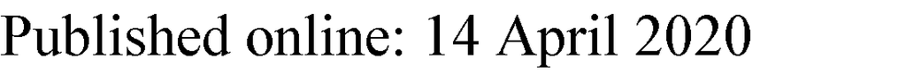

1.<sup>References</sup>

Boison D. New insights into the mechanisms of the ketogenic diet. Curr

Opin Neurol. 2017;30:187–92.

2.

Vidali S, Aminzadeh S, Lambert B, Rutherford T, Sperl W, Kofler B, et al.

Mitochondria: the ketogenic diet--a metabolism-based therapy. Int J

Biochem Cell Biol. 2015;63:55–9.

3.

Martin-McGill KJ, Jackson CF, Bresnahan R, Levy RG, Cooper PN. Ketogenic

diets for drug-resistant epilepsy. Cochrane Database Syst Rev. 2018;11:

CD001903.

4.

Di Lorenzo C, Coppola G, Di Lenola D, Evangelista M, Sirianni G, Rossi P,

et al. Efficacy of modified Atkins ketogenic diet in chronic cluster headache:

an open-label, single-arm, clinical trial. Front Neurol. 2018;9:64.

5.

Matsuzaki T, Sasaki K, Tanizaki Y, Hata J, Fujimi K, Matsui Y, et al. Insulin

resistance is associated with the pathology of Alzheimer disease: the

Hisayama Study. Neurology. 2010;75:764–70.

6.

El-Lebedy D, Raslan HM, Mohammed AM. Apolipoprotein E gene

polymorphism and risk of type 2 diabetes and cardiovascular disease.

Cardiovasc Diabetol. 2016;15:12.

7.

Swerdlow RH. Mitochondria and cell bioenergetics: increasingly recognized

components and a possible etiologic cause of Alzheimer’s disease. Antioxid

Redox Signal. 2012;16:1434–55.

8.

Cunnane SC, Courchesne-Loyer A, Vandenberghe C, St-Pierre V, Fortier M,

Hennebelle M, et al. Can ketones help rescue brain fuel supply in later life?

Implications for cognitive health during aging and the treatment of

Alzheimer’s disease. Front Mol Neurosci. 2016;9:53.

9.

Noh HS, Hah Y-S, Nilufar R, Han J, Bong J-H, Kang SS, et al. Acetoacetate

protects neuronal cells from oxidative glutamate toxicity. J Neurosci Res.

2006;83:702–9.

10.

Bough KJ, Wetherington J, Hassel B, Pare JF, Gawryluk JW, Greene JG, et al.

Mitochondrial biogenesis in the anticonvulsant mechanism of the ketogenic

diet. Ann Neurol. 2006;60:223–35.

11.

Masino SA, Kawamura M, Wasser CD, Wasser CA, Pomeroy LT, Ruskin DN.

Adenosine, ketogenic diet and epilepsy: the emerging therapeutic

relationship between metabolism and brain activity. Curr Neuropharmacol.

2009;7:257–68.

12.

Kashiwaya Y, Takeshima T, Mori N, Nakashima K, Clarke K, Veech RL. D-β-

hydroxybutyrate protects neurons in models of Alzheimer’s and Parkinson’s

disease. Proc Natl Acad Sci U S A. 2000;97:5440–4.

13.

Jeong EA, Jeon BT, Shin HJ, Kim N, Lee DH, Kim HJ, et al. Ketogenic diet-

induced peroxisome proliferator-activated receptor-γ activation decreases

neuroinflammation in the mouse hippocampus after kainic acid-induced

seizures. Exp Neurol. 2011;232:195–202.

14.

Broom GM, Shaw IC, Rucklidge JJ. The ketogenic diet as a potential

treatment and prevention strategy for Alzheimer’s disease. Nutr Burbank Los

Angel Cty Calif. 2019;60:118–21.

15.

Włodarek D. Role of ketogenic diets in neurodegenerative diseases

(Alzheimer’s disease and Parkinson’s disease). Nutrients. 2019;11. https://doi.

org/10.3390/nu11010169.

16.

Moher D, Liberati A, Tetzlaff J, Altman DG, PRISMA Group. Preferred

Reporting Items for Systematic Reviews and Meta-Analyses: the PRISMA

statement. PLoS Med. 2009;6:e1000097.

17.

Aso E, Semakova J, Joda L, Semak V, Halbaut L, Calpena A, et al.

Triheptanoin supplementation to ketogenic diet curbs cognitive

impairment in APP/PS1 mice used as a model of familial Alzheimer’s

disease. Curr Alzheimer Res. 2013;10:290–7.

18.

Beckett TL, Studzinski CM, Keller JN, Paul Murphy M, Niedowicz DM. A

ketogenic diet improves motor performance but does not affect β-amyloid

levels in a mouse model of Alzheimer’s disease. Brain Res. 2013;1505:61–7.

19.

Brownlow ML, Benner L, D’Agostino D, Gordon MN, Morgan D. Ketogenic

diet improves motor performance but not cognition in two mouse models

of Alzheimer’s pathology. PLoS One. 2013;8:e75713.

20.

Hernandez AR, Hernandez CM, Campos KT, Truckenbrod LM, Sakarya Y,

McQuail JA, et al. The antiepileptic ketogenic diet alters hippocampal

transporter levels and reduces adiposity in aged rats. J Gerontol A Biol Sci

Med Sci. 2018;73:450–8.

21.

Hernandez AR, Hernandez CM, Campos K, Truckenbrod L, Federico Q, Moon

B, et al. A ketogenic diet improves cognition and has biochemical effects in

prefrontal cortex that are dissociable from hippocampus. Front Aging

Neurosci. 2018;10:391.

22.

Kashiwaya Y, Bergman C, Lee J-H, Wan R, King MT, Mughal MR, et al. A

ketone ester diet exhibits anxiolytic and cognition-sparing properties, and

lessens amyloid and tau pathologies in a mouse model of Alzheimer’s

disease. Neurobiol Aging. 2013;34:1530–9.

23.

Newman JC, Covarrubias AJ, Zhao M, Yu X, Gut P, Ng C-P, et al. Ketogenic

diet reduces midlife mortality and improves memory in aging mice. Cell

Metab. 2017;26:547–57 e8.

24.

Pan Y, Larson B, Araujo JA, Lau W, de Rivera C, Santana R, et al. Dietary

supplementation with medium-chain TAG has long-lasting cognition-

enhancing effects in aged dogs. Br J Nutr. 2010;103:1746–54.

25.

Pawlosky RJ, Kemper MF, Kashiwaya Y, King MT, Mattson MP, Veech RL.

Effects of a dietary ketone ester on hippocampal glycolytic and tricarboxylic

acid cycle intermediates and amino acids in a 3xTgAD mouse model of

Alzheimer’s disease. J Neurochem. 2017;141:195–207.

26.

Van der Auwera I, Wera S, Van Leuven F, Henderson ST. A ketogenic diet

reduces amyloid beta 40 and 42 in a mouse model of Alzheimer’s disease.

Nutr Metab. 2005;2:28.

27.

Wang D, Mitchell ES. Cognition and synaptic-plasticity related changes in

aged rats supplemented with 8- and 10-carbon medium chain triglycerides.

PLoS One. 2016;11:e0160159.

28.

Fortier M, Castellano C-A, Croteau E, Langlois F, Bocti C, St-Pierre V, et al. A

ketogenic drink improves brain energy and some measures of cognition in

mild cognitive impairment. Alzheimers Dement J Alzheimers Assoc. 2019;15:

625–34.

29.

Ota M, Matsuo J, Ishida I, Takano H, Yokoi Y, Hori H, et al. Effects of a

medium-chain triglyceride-based ketogenic formula on cognitive function

in patients with mild-to-moderate Alzheimer’s disease. Neurosci Lett. 2019

Jan 18;690:232–6.

30.

Torosyan N, Sethanandha C, Grill JD, Dilley ML, Lee J, Cummings JL, et al.

Changes in regional cerebral blood flow associated with a 45 day course of

the ketogenic agent, caprylidene, in patients with mild to moderate

Alzheimer’s disease: results of a randomized, double-blinded, pilot study.

Exp Gerontol. 2018;111:118–21.

31.

Taylor MK, Sullivan DK, Mahnken JD, Burns JM, Swerdlow RH. Feasibility and

efficacy data from a ketogenic diet intervention in Alzheimer’s disease.

Alzheimers Dement N Y N. 2018;4:28–36.

32.

Abe S, Ezaki O, Suzuki M. Medium-chain triglycerides in combination with

leucine and vitamin D benefit cognition in frail elderly adults: a randomized

controlled trial. J Nutr Sci Vitaminol (Tokyo). 2017;63:133–40.

33.

Ota M, Matsuo J, Ishida I, Hattori K, Teraishi T, Tonouchi H, et al. Effect of a

ketogenic meal on cognitive function in elderly adults: potential for

cognitive enhancement. Psychopharmacology. 2016;233:3797–802.

34.

Ohnuma T, Toda A, Kimoto A, Takebayashi Y, Higashiyama R, Tagata Y, et al.

Benefits of use, and tolerance of, medium-chain triglyceride medical food in

the management of Japanese patients with Alzheimer’s disease: a

prospective, open-label pilot study. Clin Interv Aging. 2016;11:29–36.

35.

Rebello CJ, Keller JN, Liu AG, Johnson WD, Greenway FL. Pilot feasibility and

safety study examining the effect of medium chain triglyceride

supplementation in subjects with mild cognitive impairment: a randomized

controlled trial. BBA Clin. 2015;3:123–5.

36.

Krikorian R, Shidler MD, Dangelo K, Couch SC, Benoit SC, Clegg DJ. Dietary

ketosis enhances memory in mild cognitive impairment. Neurobiol Aging.

2012;33:425 e19–27.

37.

Henderson ST, Vogel JL, Barr LJ, Garvin F, Jones JJ, Costantini LC. Study of

the ketogenic agent AC-1202 in mild to moderate Alzheimer’s disease: a

randomized, double-blind, placebo-controlled, multicenter trial. Nutr Metab.

2009;6:31.

38.

Reger MA, Henderson ST, Hale C, Cholerton B, Baker LD, Watson GS, et al.

Effects of beta-hydroxybutyrate on cognition in memory-impaired adults.

Neurobiol Aging. 2004;25:311–4.

39.

Huang Q, Ma S, Tominaga T, Suzuki K, Liu C. An 8-week, low carbohydrate,

high fat, ketogenic diet enhanced exhaustive exercise capacity in mice part

2: effect on fatigue recovery, post-exercise biomarkers and anti-oxidation

capacity. Nutrients. 2018;10. https://doi.org/10.3390/nu10101339.

40.

Ma S, Huang Q, Tominaga T, Liu C, Suzuki K. An 8-week ketogenic

diet alternated interleukin-6, ketolytic and lipolytic gene expression, and

enhanced exercise capacity in mice. Nutrients. 2018;10. https://doi.org/10.

3390/nu10111696.

41.

Ma S, Huang Q, Yada K, Liu C, Suzuki K. An 8-week ketogenic low

carbohydrate, high fat diet enhanced exhaustive exercise capacity in mice.

Nutrients. 2018;10. https://doi.org/10.3390/nu10060673.

42.

Wang J, Ho L, Qin W, Rocher AB, Seror I, Humala N, et al. Caloric restriction

attenuates beta-amyloid neuropathology in a mouse model of Alzheimer’s

disease. FASEB J Off Publ Fed Am Soc Exp Biol. 2005;19:659–61.

43.

Hall AM, Roberson ED. Mouse models of Alzheimer’s disease. Brain Res Bull.

2012;88:3–12.

44.

Bolla AM, Caretto A, Laurenzi A, Scavini M, Piemonti L. Low-carb and

ketogenic diets in type 1 and type 2 diabetes. Nutrients. 2019;11. https://

doi.org/10.3390/nu11050962.

45.

Nordmann AJ, Nordmann A, Briel M, Keller U, Yancy WS, Brehm BJ, et al.

Effects of low-carbohydrate vs low-fat diets on weight loss and

cardiovascular risk factors: a meta-analysis of randomized controlled trials.

Arch Intern Med. 2006;166:285–93.

46.

Castellano C-A, Nugent S, Paquet N, Tremblay S, Bocti C, Lacombe G, et al.

Lower brain 18F-fluorodeoxyglucose uptake but normal 11C-acetoacetate

metabolism in mild Alzheimer’s disease dementia. J Alzheimers Dis JAD.

2015;43:1343–53.

47.

Martínez-Lapiscina EH, Galbete C, Corella D, Toledo E, Buil-Cosiales P, Salas-

Salvado J, et al. Genotype patterns at CLU, CR1, PICALM and APOE,

cognition and Mediterranean diet: the PREDIMED-NAVARRA trial. Genes

Nutr. 2014;9:393.

48.

Mehta D, Jackson R, Paul G, Shi J, Sabbagh M. Why do trials for Alzheimer’s

disease drugs keep failing? A discontinued drug perspective for 2010-2015.

Expert Opin Investig Drugs. 2017;26:735–9.

49.

Sanders CL, Wengreen HJ, Schwartz S, Behrens SJ, Corcoran C, Lyketsos CG,

et al. Nutritional status is associated with severe dementia and mortality:

the Cache County Dementia Progression Study. Alzheimer Dis Assoc Disord.

2018;32:298–304.

Publisher’s Note

Springer Nature remains neutral with regard to jurisdictional claims in

published maps and institutional affiliations.